# Data PreProcessing

Aishat Sadiq

2024-01-31

## Houston, we have a problem! | Big Data

How much data is created each day?

[It’s estimated that 1.7 MB of data are created every second for every person on earth—the same amount of data needed to store an 850 page book, per second. Researchers believe that data consumption will increase by 23% annually until 2025](https://time.com/6108001/data-protection-richard-stengel/)

## Folder structure

subdirectories: raw data, processed data, code, documentation

- getwd, working directory should be code folder

```r
###### run getwd()
getwd()
```

```
## [1] "Z:/jrg363/Workshops Sp24/R Data Processing AIshat/Final/Code"
```

```r
###### run list.files() to see all files in working directory
list.files()
```

```
## [1] "Data_Preproc_V2.html"       "Data_Preproc_V2.md"
## [3] "DataPreprocessing.Rmd"      "DataPreprocessing_script.R"
## [5] "mmALL_073120_csv.RData"
```

```r
###### Run list.files() with pattern = "Preproc" to find specific files
list.files(pattern = "Preproc")
```

```
## [1] "Data_Preproc_V2.html"       "Data_Preproc_V2.md"
## [3] "DataPreprocessing.Rmd"      "DataPreprocessing_script.R"
```

- relative paths and reproducibility

Data Structure

- A `data.frame` is a collection of vectors of identical lengths. Each vector represents a column, and each vector can be of a different data type (e.g., characters, integers, factors).
- You should separate the original data (raw data) from intermediate datasets that you may create for the need of a particular analysis. For instance, you may want to create a `data/` directory within your working directory that stores the raw data, and have a `data_output/` directory for intermediate datasets and a `figure_output/` directory for the plots you will generate.

## Why Does It Matter?

**Tidy data…**

1. Makes it easier to focus on manipulating and analyzing data
2. Makes data visualization simpler and more intuitive
3. Help ML algorithms perform and learn more effectively

> “Modeling is the driving inspiration of this work because most modeling tools work best with tidy datasets.” Hadley Wickham —-

## Load Packages/Libraries

- Base R vs. packages
- Tidyverse package was created by Hadley Wickham. Learn more about the ‘tidyverse’ online at https://www.tidyverse.org or https://github.com/tidyverse/tidyverse
- Key information: Version, Depends, Imports

```r
## install.packages("tidyverse")
library(tidyverse)
library(help = "tidyverse")
```

## Import messy data

- Easiest Option: Download from github
- Intermediate Option: Download directly from site: [Harvard Dataverse>Mass Mobilization Data Project Dataverse](https://dataverse.harvard.edu/dataset.xhtml?persistentId=doi:10.7910/DVN/HTTWYL)

Raw Data Files:

- mmALL_073120_csv.tab - .csv file
- mmALL_073120_v16.tab - Stata file
- Both have the same number of variables and observations!
- Click the triangle to the right of the download/access file icon > Select RData*
- If the original file was created in state it is usually better to download the Stata file & convert in RStudio to maintain attributes like column labels.

## Import messy data cont.

- Depending on your file type, “read in” the data.

```r
###### Method 1 ######
# Mass_Mobilizaton_Data <- haven::read_dta("Mass_Mobilizaton_Data.dta")

###### Method 2 ######
load("../Data/mmALL_073120_csv.RData")
View(mmALL_073120_csv)

###### Method 3 w/dupes ######
mmALL_073120_csv <- read_csv("../Data/mmALL_073120_csv.csv")
View(mmALL_073120_csv)
```

## Background on Mass Mobilization (MM)

The Mass Mobilization (MM) data are an effort to understand citizen movements against governments, what citizens want when they demonstrate against governments, and how governments respond to citizens. The project codes protests against governments - the data cover 162 countries between 1990 and March 2020. For each protest event, the project records protester demands, government responses, protest location, and protester identities. The unit of observation is the protest-country-year, where protests are recorded individually within each country and year.

The Principle Investigators for the Mass Mobilization project are David H. Clark (Binghamton University) and Patrick M. Regan (University of Notre Dame). The Mass Mobilization project is sponsored by the Political Instability Task Force (PITF). The PITF is funded by the Central Intelligence Agency. The views expressed herein are the Principal Investigators’ alone and do not represent the views of the US Government.

## Define Research Question…to select key variables

Using the Mass Mobilization data, what are the geopolitical differences in citizen participation in protest movements against governments over time? In other words, can we determine if the number of participants and the number of protests change by country, region, or year.

## Subset Columns of Interest

- Use filter() to get the rows you want
- Use select() to get the columns you want
- Use pipe commands (|> vs %>%) to input/output the data you want
- Pipes in R look like `%>%` and are made available via the `magrittr` package installed as part of `dplyr`
- Data will not save if it created into an object, unless using the last baseR script

```r
###### View all column names in df ######
colnames(mmALL_073120_csv)
```

```
##  [1] "id"                    "country"               "ccode"
##  [4] "year"                  "region"                "protest"
##  [7] "protestnumber"         "startday"              "startmonth"
## [10] "startyear"             "endday"                "endmonth"
## [13] "endyear"               "protesterviolence"     "location"
## [16] "participants_category" "participants"          "protesteridentity"
## [19] "protesterdemand1"      "protesterdemand2"      "protesterdemand3"
## [22] "protesterdemand4"      "stateresponse1"        "stateresponse2"
## [25] "stateresponse3"        "stateresponse4"        "stateresponse5"
## [28] "stateresponse6"        "stateresponse7"        "sources"
## [31] "notes"
```

```r
###### Braindump all potentially relevant variables/columns ######
PreprocData <- mmALL_073120_csv %>%
  dplyr::select(protest, participants, participants_category, protestnumber, protesterviolence, region, year, country, ccode, id, startday, startmonth, startyear, endday, endmonth, endyear)

###### Filter rows by Region ######
preprec_North_America <- PreprocData %>%
  filter(region == "North America")
View(preprec_North_America)

###### Remove the year column ######
PreprocData %>% select(-year)
```

```
## # A tibble: 17,162 × 15
##    protest participants participants_category protestnumber protesterviolence
##      <dbl> <chr>        <chr>                         <dbl>             <dbl>
##  1       1 1000s        <NA>                              1                 0
##  2       1 1000s        <NA>                              1                 0
##  3       1 1000         <NA>                              2                 0
##  4       1 500          <NA>                              3                 0
##  5       1 100s         <NA>                              4                 1
##  6       1 950          <NA>                              5                 1
##  7       1 200          <NA>                              6                 0
##  8       1 110000       <NA>                              1                 0
##  9       1 110000       <NA>                              2                 0
## 10       1 1000         <NA>                              1                 1
## # ℹ 17,152 more rows
## # ℹ 10 more variables: region <chr>, country <chr>, ccode <dbl>, id <dbl>,
## #   startday <dbl>, startmonth <dbl>, startyear <dbl>, endday <dbl>,
## #   endmonth <dbl>, endyear <dbl>
```

```r
###### Rename the columns w/ dplry and base R ######
PreprocData %>%
  rename(countrycode = ccode)
```

```
## # A tibble: 17,162 × 16
##    protest participants participants_category protestnumber protesterviolence
##      <dbl> <chr>        <chr>                         <dbl>             <dbl>
##  1       1 1000s        <NA>                              1                 0
##  2       1 1000s        <NA>                              1                 0
##  3       1 1000         <NA>                              2                 0
##  4       1 500          <NA>                              3                 0
##  5       1 100s         <NA>                              4                 1
##  6       1 950          <NA>                              5                 1
##  7       1 200          <NA>                              6                 0
##  8       1 110000       <NA>                              1                 0
##  9       1 110000       <NA>                              2                 0
## 10       1 1000         <NA>                              1                 1
## # ℹ 17,152 more rows
## # ℹ 11 more variables: region <chr>, year <dbl>, country <chr>,
## #   countrycode <dbl>, id <dbl>, startday <dbl>, startmonth <dbl>,
## #   startyear <dbl>, endday <dbl>, endmonth <dbl>, endyear <dbl>
```

```r
names(PreprocData)[names(PreprocData) == "ccode"] <- "countrycode"
```

```r
###### All together, magic of the pipe tool ######

PreprocData <- mmALL_073120_csv %>%
  dplyr::select(protest, participants, participants_category, protestnumber, protesterviolence, region, year, country, ccode, id, startday, startmonth, startyear, endday, endmonth, endyear) %>%
  select(-year) %>%
  rename(countrycode = ccode)

###### View all column names in new df ######
colnames(PreprocData)
```

```
##  [1] "protest"               "participants"          "participants_category"
##  [4] "protestnumber"         "protesterviolence"     "region"
##  [7] "country"               "countrycode"           "id"
## [10] "startday"              "startmonth"            "startyear"
## [13] "endday"                "endmonth"              "endyear"
```

## Transforming Variable Type

- Use str() function to detail your dataframe’s structure.
  - `str()` - structure of the object and information about the class, length and content of each column

```r
str(PreprocData)
```

```
## tibble [17,162 × 15] (S3: tbl_df/tbl/data.frame)
##  $ protest              : num [1:17162] 1 1 1 1 1 1 1 1 1 1 ...
##  $ participants         : chr [1:17162] "1000s" "1000s" "1000" "500" ...
##  $ participants_category: chr [1:17162] NA NA NA NA ...
##  $ protestnumber        : num [1:17162] 1 1 2 3 4 5 6 1 2 1 ...
##  $ protesterviolence    : num [1:17162] 0 0 0 0 1 1 0 0 0 1 ...
##  $ region               : chr [1:17162] "North America" "North America" "North America" "North America" ...
##  $ country              : chr [1:17162] "Canada" "Canada" "Canada" "Canada" ...
##  $ countrycode          : num [1:17162] 20 20 20 20 20 20 20 20 20 20 ...
##  $ id                   : num [1:17162] 2.02e+08 2.02e+08 2.02e+08 2.02e+08 2.02e+08 ...
##  $ startday             : num [1:17162] 15 15 25 1 12 14 19 10 28 4 ...
##  $ startmonth           : num [1:17162] 1 1 6 7 7 8 9 9 9 5 ...
##  $ startyear            : num [1:17162] 1990 1990 1990 1990 1990 ...
##  $ endday               : num [1:17162] 15 15 25 1 6 15 19 17 2 5 ...
##  $ endmonth             : num [1:17162] 1 1 6 7 9 8 9 9 10 5 ...
##  $ endyear              : num [1:17162] 1990 1990 1990 1990 1990 ...
```

```r
## transforms selected vars
PreprocData_transformed <- PreprocData %>%
mutate(
  participants = as.numeric(participants),
  participants_category = as.factor(participants_category),
  protestnumber = as.integer(protestnumber),
  protesterviolence = as.factor(protesterviolence),
  startmonth = as.integer(startmonth),
  startyear = as.integer(startyear),
  endday = as.integer(endday),
  endmonth = as.integer(endmonth),
  endyear = as.integer(endyear),
  region = as.factor(region),
  country = as.factor(country)
)
## Known warning message for participants NA numeric data

###### reassign levels of factor variable: participants_category ######
levels(PreprocData_transformed$participants_category) <- list(
       ">10000" = ">10000",
       "100-999" = "100-999",
       "1000-1999" = "1000-1999",
       "2000-4999" = "2000-4999",
       "50-99" = "50-99",
       "5000-10000" = "5000-10000",
       "NA"="NA")
```

## Identifying and removing duplicate observations/rows

- With big data, it is inefficient to manually remove duplicates
- Also, using code makes for a more reproducible result

```r
rownames(PreprocData_transformed)
```

```
##     [1] "1"     "2"     "3"     "4"     "5"     "6"     "7"     "8"     "9"
##    [10] "10"    "11"    "12"    "13"    "14"    "15"    "16"    "17"    "18"
##    [19] "19"    "20"    "21"    "22"    "23"    "24"    "25"    "26"    "27"
##    [28] "28"    "29"    "30"    "31"    "32"    "33"    "34"    "35"    "36"
##    [37] "37"    "38"    "39"    "40"    "41"    "42"    "43"    "44"    "45"
##    [46] "46"    "47"    "48"    "49"    "50"    "51"    "52"    "53"    "54"
##    [55] "55"    "56"    "57"    "58"    "59"    "60"    "61"    "62"    "63"
##    [64] "64"    "65"    "66"    "67"    "68"    "69"    "70"    "71"    "72"
##    [73] "73"    "74"    "75"    "76"    "77"    "78"    "79"    "80"    "81"
##    [82] "82"    "83"    "84"    "85"    "86"    "87"    "88"    "89"    "90"
##    [91] "91"    "92"    "93"    "94"    "95"    "96"    "97"    "98"    "99"
##   [100] "100"   "101"   "102"   "103"   "104"   "105"   "106"   "107"   "108"
##   [109] "109"   "110"   "111"   "112"   "113"   "114"   "115"   "116"   "117"
##   [118] "118"   "119"   "120"   "121"   "122"   "123"   "124"   "125"   "126"
##   [127] "127"   "128"   "129"   "130"   "131"   "132"   "133"   "134"   "135"
```

[output cut: 1892 more lines]

```r
###### Method 1: Remove duplicate rows ######
PreprocData2 <- PreprocData_transformed[!duplicated(PreprocData_transformed), ]

###### Method 2: Remove duplicates by single column ######
PreprocData2 <- PreprocData_transformed[!duplicated(PreprocData_transformed$id), ]

###### Method 3: Using dplyr - Remove duplicate rows (all columns)
PreprocData2 <- PreprocData_transformed %>% distinct()
```

## Remove Missing Data

- What should we do when we encounter missing data in our datasets? * Listwise-deletion/ Complete Case Analysis - watch what happens to the number of observations! * Mean/median Imputation * Multiple Imputation
- Ask yourself if you were to guess what those missing values were without any additional information, which would you choose?
- Listwise-deletion/ Complete Case Analysis
- When dealing with simple statistics like the mean, the easiest way to ignore `NA` (the missing data) is to use `na.rm=TRUE` (`rm` stands for remove).

```r
###### Find missing cells
is.na(PreprocData2)
```

```
##          protest participants participants_category protestnumber
##     [1,]   FALSE         TRUE                  TRUE         FALSE
##     [2,]   FALSE        FALSE                  TRUE         FALSE
##     [3,]   FALSE        FALSE                  TRUE         FALSE
##     [4,]   FALSE         TRUE                  TRUE         FALSE
##     [5,]   FALSE        FALSE                  TRUE         FALSE
##     [6,]   FALSE        FALSE                  TRUE         FALSE
##     [7,]   FALSE        FALSE                  TRUE         FALSE
##     [8,]   FALSE        FALSE                  TRUE         FALSE
##     [9,]   FALSE        FALSE                  TRUE         FALSE
##    [10,]   FALSE         TRUE                  TRUE         FALSE
##    [11,]   FALSE         TRUE                  TRUE         FALSE
##    [12,]   FALSE        FALSE                  TRUE         FALSE
##    [13,]   FALSE        FALSE                  TRUE         FALSE
##    [14,]   FALSE        FALSE                  TRUE         FALSE
```

[output cut: 19987 more lines]

```r
###### Find rows w/ NA
complete.cases(PreprocData2)
```

```
##     [1] FALSE FALSE FALSE FALSE FALSE FALSE FALSE FALSE FALSE FALSE FALSE FALSE
##    [13] FALSE FALSE FALSE FALSE FALSE FALSE FALSE FALSE FALSE FALSE FALSE FALSE
##    [25] FALSE FALSE FALSE FALSE FALSE FALSE FALSE FALSE FALSE FALSE FALSE FALSE
##    [37] FALSE FALSE FALSE FALSE FALSE FALSE FALSE FALSE FALSE FALSE FALSE FALSE
##    [49] FALSE FALSE FALSE  TRUE FALSE FALSE  TRUE  TRUE  TRUE  TRUE FALSE  TRUE
##    [61] FALSE FALSE FALSE FALSE FALSE FALSE FALSE FALSE FALSE FALSE FALSE FALSE
##    [73] FALSE FALSE FALSE FALSE FALSE FALSE FALSE FALSE FALSE FALSE FALSE FALSE
##    [85] FALSE FALSE FALSE FALSE FALSE FALSE FALSE FALSE FALSE FALSE FALSE FALSE
##    [97] FALSE FALSE FALSE FALSE FALSE FALSE FALSE FALSE FALSE FALSE FALSE FALSE
##   [109] FALSE FALSE FALSE FALSE FALSE FALSE FALSE FALSE FALSE FALSE FALSE FALSE
##   [121] FALSE FALSE FALSE FALSE FALSE FALSE FALSE FALSE FALSE FALSE FALSE FALSE
##   [133] FALSE FALSE FALSE FALSE FALSE FALSE FALSE FALSE FALSE FALSE FALSE FALSE
##   [145] FALSE FALSE FALSE FALSE FALSE FALSE FALSE FALSE FALSE FALSE FALSE FALSE
##   [157] FALSE FALSE FALSE FALSE FALSE FALSE FALSE FALSE FALSE FALSE FALSE FALSE
##   [169] FALSE FALSE FALSE FALSE FALSE FALSE FALSE FALSE FALSE FALSE FALSE  TRUE
```

[output cut: 1414 more lines]

```r
###### Count NA
sum(is.na(PreprocData2))       ## count all missing observations
```

```
## [1] 29709
```

```r
colSums(is.na(PreprocData2))   ## count the number of missing values in each column
```

```
##               protest          participants participants_category
##                     0                  9628                  7258
##         protestnumber     protesterviolence                region
##                     0                  1387                     0
##               country           countrycode                    id
##                     0                     0                     0
##              startday            startmonth             startyear
##                  1906                  1906                  1906
##                endday              endmonth               endyear
##                  1906                  1906                  1906
```

```r
######  Listwise NA Removal and confirmation - compare number of observations
Preproc_NArm <- na.exclude(PreprocData2)

######  Other methods of Listwise NA removal
PreprocData2[complete.cases(PreprocData2),]
```

```
## # A tibble: 3,079 × 15
##    protest participants participants_category protestnumber protesterviolence
##      <dbl>        <dbl> <fct>                         <int> <fct>
##  1       1           50 50-99                             1 0
##  2       1          100 100-999                           1 0
##  3       1           50 50-99                             2 0
##  4       1           50 50-99                             3 0
##  5       1           60 50-99                             4 0
##  6       1           50 50-99                             1 0
##  7       1          400 100-999                           1 0
##  8       1          100 100-999                           2 0
##  9       1         2000 2000-4999                         2 0
## 10       1         1500 1000-1999                         1 1
## # ℹ 3,069 more rows
## # ℹ 10 more variables: region <fct>, country <fct>, countrycode <dbl>,
## #   id <dbl>, startday <dbl>, startmonth <int>, startyear <int>, endday <int>,
## #   endmonth <int>, endyear <int>
```

```r
na.omit(PreprocData2)
```

```
## # A tibble: 3,079 × 15
##    protest participants participants_category protestnumber protesterviolence
##      <dbl>        <dbl> <fct>                         <int> <fct>
##  1       1           50 50-99                             1 0
##  2       1          100 100-999                           1 0
##  3       1           50 50-99                             2 0
##  4       1           50 50-99                             3 0
##  5       1           60 50-99                             4 0
##  6       1           50 50-99                             1 0
##  7       1          400 100-999                           1 0
##  8       1          100 100-999                           2 0
##  9       1         2000 2000-4999                         2 0
## 10       1         1500 1000-1999                         1 1
## # ℹ 3,069 more rows
## # ℹ 10 more variables: region <fct>, country <fct>, countrycode <dbl>,
## #   id <dbl>, startday <dbl>, startmonth <int>, startyear <int>, endday <int>,
## #   endmonth <int>, endyear <int>
```

```r
sum(is.na(PreprocData2))
```

```
## [1] 29709
```

```r
PreprocData2 %>% drop_na()
```

```
## # A tibble: 3,079 × 15
##    protest participants participants_category protestnumber protesterviolence
##      <dbl>        <dbl> <fct>                         <int> <fct>
##  1       1           50 50-99                             1 0
##  2       1          100 100-999                           1 0
##  3       1           50 50-99                             2 0
##  4       1           50 50-99                             3 0
##  5       1           60 50-99                             4 0
##  6       1           50 50-99                             1 0
##  7       1          400 100-999                           1 0
##  8       1          100 100-999                           2 0
##  9       1         2000 2000-4999                         2 0
## 10       1         1500 1000-1999                         1 1
## # ℹ 3,069 more rows
## # ℹ 10 more variables: region <fct>, country <fct>, countrycode <dbl>,
## #   id <dbl>, startday <dbl>, startmonth <int>, startyear <int>, endday <int>,
## #   endmonth <int>, endyear <int>
```

```r
######  Remove missing values of specified single column
PreprocData2 %>% drop_na(participants)
```

```
## # A tibble: 7,517 × 15
##    protest participants participants_category protestnumber protesterviolence
##      <dbl>        <dbl> <fct>                         <int> <fct>
##  1       1         1000 <NA>                              2 0
##  2       1          500 <NA>                              3 0
##  3       1          950 <NA>                              5 1
##  4       1          200 <NA>                              6 0
##  5       1       110000 <NA>                              1 0
##  6       1       110000 <NA>                              2 0
##  7       1         1000 <NA>                              1 1
##  8       1        10000 <NA>                              1 0
##  9       1         6000 <NA>                              2 0
## 10       1         3000 <NA>                              1 0
## # ℹ 7,507 more rows
## # ℹ 10 more variables: region <fct>, country <fct>, countrycode <dbl>,
## #   id <dbl>, startday <dbl>, startmonth <int>, startyear <int>, endday <int>,
## #   endmonth <int>, endyear <int>
```

```r
######  Remove missing values of specified multiple columns
PreprocData2 %>% drop_na(participants, protesterviolence)
```

```
## # A tibble: 7,517 × 15
##    protest participants participants_category protestnumber protesterviolence
##      <dbl>        <dbl> <fct>                         <int> <fct>
##  1       1         1000 <NA>                              2 0
##  2       1          500 <NA>                              3 0
##  3       1          950 <NA>                              5 1
##  4       1          200 <NA>                              6 0
##  5       1       110000 <NA>                              1 0
##  6       1       110000 <NA>                              2 0
##  7       1         1000 <NA>                              1 1
##  8       1        10000 <NA>                              1 0
##  9       1         6000 <NA>                              2 0
## 10       1         3000 <NA>                              1 0
## # ℹ 7,507 more rows
## # ℹ 10 more variables: region <fct>, country <fct>, countrycode <dbl>,
## #   id <dbl>, startday <dbl>, startmonth <int>, startyear <int>, endday <int>,
## #   endmonth <int>, endyear <int>
```

```r
######  confirm no missing observations in new df
sum(is.na(Preproc_NArm))
```

```
## [1] 0
```

```r
######  confirm no missing values in each column of new df
colSums(is.na(Preproc_NArm))
```

```
##               protest          participants participants_category
##                     0                     0                     0
##         protestnumber     protesterviolence                region
##                     0                     0                     0
##               country           countrycode                    id
##                     0                     0                     0
##              startday            startmonth             startyear
##                     0                     0                     0
##                endday              endmonth               endyear
##                     0                     0                     0
```

## Multiple Imputation of NAs

- In statistics, imputation means “filling in the data.” Mice is an algorithm that allows us to fill in the missing data by creating a multivariate imputation model and conditional probability distribution for each variable in our dataset.
- Think about it as an iterative series of matrix calculations!
- mice includes functions for diagnostic plots to inspect the quality of the imputations
- When to not use mice? Large p, small n.
- `summary()` - summary statistics for each column

Mean/median Imputation steps: - Start the mutate() function. - Specify the column in which you want to replace the missing values. - Use the ifelse() function to identify NA’s, and once found, replace them with the median. - Finish the mutate() function.

```r
###### Impute mean for participants column ######
preproc_participants_mean_impute <- PreprocData2 %>%
  mutate(participants = ifelse(is.na(participants),
                            mean(participants, na.rm = T),
                            participants))
summary(preproc_participants_mean_impute$participants)
```

```
##    Min. 1st Qu.  Median    Mean 3rd Qu.    Max.
##      29    1000   23243   23243   23243 7000000
```

```r
###### Impute median for participants column ######
preproc_participants_median_impute <- PreprocData2 %>%
  mutate(participants = ifelse(is.na(participants),
                            median(participants, na.rm = T),
                            participants))
summary(preproc_participants_median_impute$participants)
```

```
##    Min. 1st Qu.  Median    Mean 3rd Qu.    Max.
##      29    1000    1000   10752    1000 7000000
```

```r
###### Impute mean for all numeric columns ######
preproc_mean_impute <- PreprocData2 %>%
  mutate_if(is.numeric, function(x) ifelse(is.na(x), mean(x, na.rm = T), x))
summary(preproc_mean_impute)
```

```
##     protest        participants     participants_category protestnumber
##  Min.   :0.0000   Min.   :     29   100-999   :3204       Min.   :  0.000
##  1st Qu.:1.0000   1st Qu.:   1000   50-99     :2508       1st Qu.:  1.000
##  Median :1.0000   Median :  23243   2000-4999 :1580       Median :  3.000
##  Mean   :0.8888   Mean   :  23243   >10000    :1470       Mean   :  7.406
##  3rd Qu.:1.0000   3rd Qu.:  23243   5000-10000: 642       3rd Qu.:  8.000
##  Max.   :1.0000   Max.   :7000000   (Other)   : 483       Max.   :143.000
##                                     NA's      :7258
##  protesterviolence           region               country       countrycode
##  0   :11723        Europe       :5469   United Kingdom:  578   Min.   : 20.0
##  1   : 4035        Africa       :3790   France        :  547   1st Qu.:220.0
##  NA's: 1387        Asia         :3448   Ireland       :  438   Median :434.0
##                    South America:1713   Germany       :  364   Mean   :437.9
##                    MENA         :1585   Kenya         :  353   3rd Qu.:651.0
##                    North America: 587   South Korea   :  348   Max.   :910.0
##                    (Other)      : 553   (Other)       :14517
##        id               startday       startmonth       startyear
##  Min.   :2.020e+08   Min.   : 1.00   Min.   : 1.000   Min.   :1990
##  1st Qu.:2.202e+09   1st Qu.: 9.00   1st Qu.: 4.000   1st Qu.:2000
##  Median :4.342e+09   Median :15.46   Median : 6.228   Median :2006
##  Mean   :4.381e+09   Mean   :15.46   Mean   : 6.228   Mean   :2006
##  3rd Qu.:6.512e+09   3rd Qu.:22.00   3rd Qu.: 9.000   3rd Qu.:2014
##  Max.   :9.102e+09   Max.   :31.00   Max.   :12.000   Max.   :2020
##
##      endday         endmonth         endyear
##  Min.   : 1.00   Min.   : 1.000   Min.   :1990
##  1st Qu.: 9.00   1st Qu.: 4.000   1st Qu.:2000
##  Median :15.58   Median : 6.244   Median :2006
##  Mean   :15.58   Mean   : 6.244   Mean   :2006
##  3rd Qu.:22.00   3rd Qu.: 9.000   3rd Qu.:2014
##  Max.   :31.00   Max.   :12.000   Max.   :2020
##
```

```r
###### Impute median for all numeric columns ######
preproc_median_impute <- PreprocData2 %>%
  mutate_if(is.numeric, function(x) ifelse(is.na(x), median(x, na.rm = T), x))
summary(preproc_median_impute)
```

```
##     protest        participants     participants_category protestnumber
##  Min.   :0.0000   Min.   :     29   100-999   :3204       Min.   :  0.000
##  1st Qu.:1.0000   1st Qu.:   1000   50-99     :2508       1st Qu.:  1.000
##  Median :1.0000   Median :   1000   2000-4999 :1580       Median :  3.000
##  Mean   :0.8888   Mean   :  10752   >10000    :1470       Mean   :  7.406
##  3rd Qu.:1.0000   3rd Qu.:   1000   5000-10000: 642       3rd Qu.:  8.000
##  Max.   :1.0000   Max.   :7000000   (Other)   : 483       Max.   :143.000
##                                     NA's      :7258
##  protesterviolence           region               country       countrycode
##  0   :11723        Europe       :5469   United Kingdom:  578   Min.   : 20.0
##  1   : 4035        Africa       :3790   France        :  547   1st Qu.:220.0
##  NA's: 1387        Asia         :3448   Ireland       :  438   Median :434.0
##                    South America:1713   Germany       :  364   Mean   :437.9
##                    MENA         :1585   Kenya         :  353   3rd Qu.:651.0
##                    North America: 587   South Korea   :  348   Max.   :910.0
##                    (Other)      : 553   (Other)       :14517
##        id               startday       startmonth       startyear
##  Min.   :2.020e+08   Min.   : 1.00   Min.   : 1.000   Min.   :1990
##  1st Qu.:2.202e+09   1st Qu.: 9.00   1st Qu.: 4.000   1st Qu.:2000
##  Median :4.342e+09   Median :15.00   Median : 6.000   Median :2007
##  Mean   :4.381e+09   Mean   :15.41   Mean   : 6.203   Mean   :2006
##  3rd Qu.:6.512e+09   3rd Qu.:22.00   3rd Qu.: 9.000   3rd Qu.:2014
##  Max.   :9.102e+09   Max.   :31.00   Max.   :12.000   Max.   :2020
##
##      endday         endmonth         endyear
##  Min.   : 1.00   Min.   : 1.000   Min.   :1990
##  1st Qu.: 9.00   1st Qu.: 4.000   1st Qu.:2000
##  Median :16.00   Median : 6.000   Median :2007
##  Mean   :15.63   Mean   : 6.216   Mean   :2006
##  3rd Qu.:22.00   3rd Qu.: 9.000   3rd Qu.:2014
##  Max.   :31.00   Max.   :12.000   Max.   :2020
##
```

```r
###### Group by region, Impute NAs participants & protest_length column ######
###### RUN
preproc_median_tidyimpute <- PreprocData2 %>%
  group_by(region) %>%
  mutate(participants = ifelse(is.na(participants),
                            median(participants, na.rm = TRUE),
                            participants))
colSums(is.na(preproc_median_tidyimpute))
```

```
##               protest          participants participants_category
##                     0                     0                  7258
##         protestnumber     protesterviolence                region
##                     0                  1387                     0
##               country           countrycode                    id
##                     0                     0                     0
##              startday            startmonth             startyear
##                  1906                  1906                  1906
##                endday              endmonth               endyear
##                  1906                  1906                  1906
```

```r
######  confirm no missing observations in new df
sum(is.na(preproc_median_tidyimpute))
```

```
## [1] 20081
```

```r
######  confirm no missing values in each column of new df
colSums(is.na(preproc_median_tidyimpute))
```

```
##               protest          participants participants_category
##                     0                     0                  7258
##         protestnumber     protesterviolence                region
##                     0                  1387                     0
##               country           countrycode                    id
##                     0                     0                     0
##              startday            startmonth             startyear
##                  1906                  1906                  1906
##                endday              endmonth               endyear
##                  1906                  1906                  1906
```

- Multiple Imputation using MICE
- Note: objects masked by packages!
- For more: https://www.gerkovink.com/miceVignettes/Sensitivity_analysis/Sensitivity_analysis.html

```r
######  install.packages("mice")
######  install.packages("ggmice")

library(mice)
library(ggmice)
library(help = "mice")
?mice() ## Look at Built-in univariate imputation methods for "methods = "" & Vignettes
```

```
## starting httpd help server ...
```

```
##  done
```

```r
######  run simple multiple imputation over whole df
PreprocData_imp <- mice(PreprocData2, m = 1, seed = 31415, method = "cart")
######  list the actual imputations for startyear
PreprocData_imp$imp$startyear
```

```
##          1
## 19    2010
## 20    2019
## 25    2018
## 26    2015
## 28    2004
## 39    2019
## 40    2007
## 61    2019
## 62    2016
## 63    1994
## 64    2016
## 66    2019
## 67    1994
## 68    2016
```

[output cut: 1892 more lines]

```r
######  fill data matrix
PreprocData_compl <- complete(PreprocData_imp)

View(PreprocData_compl)
colSums(is.na(PreprocData_compl))
```

```
##               protest          participants participants_category
##                     0                     0                     0
##         protestnumber     protesterviolence                region
##                     0                     0                     0
##               country           countrycode                    id
##                     0                     0                     0
##              startday            startmonth             startyear
##                     0                     0                     0
##                endday              endmonth               endyear
##                     0                     0                  1906
```

## Computing new variables

```r
######  use lubridate to correct date formatting
Preproc_dates <- preproc_median_tidyimpute %>%
  mutate(start = lubridate::make_datetime(startyear, startday, startmonth)) %>%   ## error w/o including lubridate::
  mutate(end = lubridate::make_datetime(endyear, endday, endmonth))
summary(Preproc_dates)
```

```
##     protest        participants     participants_category protestnumber
##  Min.   :0.0000   Min.   :     29   100-999   :3204       Min.   :  0.000
##  1st Qu.:1.0000   1st Qu.:    400   50-99     :2508       1st Qu.:  1.000
##  Median :1.0000   Median :   1000   2000-4999 :1580       Median :  3.000
##  Mean   :0.8888   Mean   :  10693   >10000    :1470       Mean   :  7.406
##  3rd Qu.:1.0000   3rd Qu.:   1500   5000-10000: 642       3rd Qu.:  8.000
##  Max.   :1.0000   Max.   :7000000   (Other)   : 483       Max.   :143.000
##                                     NA's      :7258
##  protesterviolence           region               country       countrycode
##  0   :11723        Europe       :5469   United Kingdom:  578   Min.   : 20.0
##  1   : 4035        Africa       :3790   France        :  547   1st Qu.:220.0
##  NA's: 1387        Asia         :3448   Ireland       :  438   Median :434.0
##                    South America:1713   Germany       :  364   Mean   :437.9
##                    MENA         :1585   Kenya         :  353   3rd Qu.:651.0
##                    North America: 587   South Korea   :  348   Max.   :910.0
##                    (Other)      : 553   (Other)       :14517
##        id               startday       startmonth       startyear
##  Min.   :2.020e+08   Min.   : 1.00   Min.   : 1.000   Min.   :1990
##  1st Qu.:2.202e+09   1st Qu.: 8.00   1st Qu.: 3.000   1st Qu.:1999
##  Median :4.342e+09   Median :15.00   Median : 6.000   Median :2007
##  Mean   :4.381e+09   Mean   :15.46   Mean   : 6.228   Mean   :2006
##  3rd Qu.:6.512e+09   3rd Qu.:23.00   3rd Qu.: 9.000   3rd Qu.:2014
##  Max.   :9.102e+09   Max.   :31.00   Max.   :12.000   Max.   :2020
##                      NA's   :1906    NA's   :1906     NA's   :1906
##      endday         endmonth         endyear
##  Min.   : 1.00   Min.   : 1.000   Min.   :1990
##  1st Qu.: 8.00   1st Qu.: 3.000   1st Qu.:1999
##  Median :16.00   Median : 6.000   Median :2007
##  Mean   :15.58   Mean   : 6.244   Mean   :2006
##  3rd Qu.:23.00   3rd Qu.: 9.000   3rd Qu.:2014
##  Max.   :31.00   Max.   :12.000   Max.   :2020
##  NA's   :1906    NA's   :1906     NA's   :1906
##      start                             end
##  Min.   :1990-01-01 00:00:00.00   Min.   :1990-01-01 00:00:00.00
##  1st Qu.:1999-10-10 00:00:00.00   1st Qu.:1999-11-01 12:00:00.00
##  Median :2008-07-11 00:00:00.00   Median :2008-08-02 00:00:00.00
##  Mean   :2007-07-18 15:19:31.49   Mean   :2007-07-23 10:47:56.88
##  3rd Qu.:2015-07-12 00:00:00.00   3rd Qu.:2015-07-12 00:00:00.00
##  Max.   :2022-07-03 00:00:00.00   Max.   :2022-07-03 00:00:00.00
##  NA's   :1906                     NA's   :1906
```

```r
######  split date/time columns
###### DO NOT RUN
Preproc_dates_sep <- Preproc_dates %>%
tidyr::separate(start, c("startyear", "startday", "startmonth"))  %>%
tidyr::separate(end, c("endyear", "endday", "endmonth"))
summary(Preproc_dates)
```

```
##     protest        participants     participants_category protestnumber
##  Min.   :0.0000   Min.   :     29   100-999   :3204       Min.   :  0.000
##  1st Qu.:1.0000   1st Qu.:    400   50-99     :2508       1st Qu.:  1.000
##  Median :1.0000   Median :   1000   2000-4999 :1580       Median :  3.000
##  Mean   :0.8888   Mean   :  10693   >10000    :1470       Mean   :  7.406
##  3rd Qu.:1.0000   3rd Qu.:   1500   5000-10000: 642       3rd Qu.:  8.000
##  Max.   :1.0000   Max.   :7000000   (Other)   : 483       Max.   :143.000
##                                     NA's      :7258
##  protesterviolence           region               country       countrycode
##  0   :11723        Europe       :5469   United Kingdom:  578   Min.   : 20.0
##  1   : 4035        Africa       :3790   France        :  547   1st Qu.:220.0
##  NA's: 1387        Asia         :3448   Ireland       :  438   Median :434.0
##                    South America:1713   Germany       :  364   Mean   :437.9
##                    MENA         :1585   Kenya         :  353   3rd Qu.:651.0
##                    North America: 587   South Korea   :  348   Max.   :910.0
##                    (Other)      : 553   (Other)       :14517
##        id               startday       startmonth       startyear
##  Min.   :2.020e+08   Min.   : 1.00   Min.   : 1.000   Min.   :1990
##  1st Qu.:2.202e+09   1st Qu.: 8.00   1st Qu.: 3.000   1st Qu.:1999
##  Median :4.342e+09   Median :15.00   Median : 6.000   Median :2007
##  Mean   :4.381e+09   Mean   :15.46   Mean   : 6.228   Mean   :2006
##  3rd Qu.:6.512e+09   3rd Qu.:23.00   3rd Qu.: 9.000   3rd Qu.:2014
##  Max.   :9.102e+09   Max.   :31.00   Max.   :12.000   Max.   :2020
##                      NA's   :1906    NA's   :1906     NA's   :1906
##      endday         endmonth         endyear
##  Min.   : 1.00   Min.   : 1.000   Min.   :1990
##  1st Qu.: 8.00   1st Qu.: 3.000   1st Qu.:1999
##  Median :16.00   Median : 6.000   Median :2007
##  Mean   :15.58   Mean   : 6.244   Mean   :2006
##  3rd Qu.:23.00   3rd Qu.: 9.000   3rd Qu.:2014
##  Max.   :31.00   Max.   :12.000   Max.   :2020
##  NA's   :1906    NA's   :1906     NA's   :1906
##      start                             end
##  Min.   :1990-01-01 00:00:00.00   Min.   :1990-01-01 00:00:00.00
##  1st Qu.:1999-10-10 00:00:00.00   1st Qu.:1999-11-01 12:00:00.00
##  Median :2008-07-11 00:00:00.00   Median :2008-08-02 00:00:00.00
##  Mean   :2007-07-18 15:19:31.49   Mean   :2007-07-23 10:47:56.88
##  3rd Qu.:2015-07-12 00:00:00.00   3rd Qu.:2015-07-12 00:00:00.00
##  Max.   :2022-07-03 00:00:00.00   Max.   :2022-07-03 00:00:00.00
##  NA's   :1906                     NA's   :1906
```

```r
######  computing new variables w/ multiple existing w/difftime()?
Preproc_dates$protest_length = difftime(Preproc_dates$end, Preproc_dates$start, units = "days")
View(Preproc_dates)
```

## Merge & Join Separate DFs

- merge, join, rbind, cbind
- modified by the “by” preposition

## Flagging and dropping outliers

When we analyze data, it’s important to recognize outliers because they can affect the accuracy of our models. Outliers can cause bias when performing statistical calculations like mean, standard deviation, and correlation on continuous variables. Although outliers can have a big impact, experts suggest not automatically removing them from our observations during analysis!!

- Methods of removal:
  - InterQuartile Range
  - Mean +/- 3 Standard Deviations
    - Median Absolute Deviation (MAD)
  - Z-score & modified Z-score
  - Statistical Tests
    - Dixon’s *Q* Test; Grubb’s test; Rosner’s test/generalized ESD many-outliers test (GESD); Chi-squared test

```r
Preproc_join <- Preproc_dates %>%
dplyr::semi_join(Preproc_dates, global_population, by = c("country", "startyear"))
View(Preproc_join)
###### Review summary stats of df to select numeric columns with possible outliers
summary(Preproc_join)
```

```
##     protest        participants     participants_category protestnumber
##  Min.   :0.0000   Min.   :     29   100-999   :3204       Min.   :  0.000
##  1st Qu.:1.0000   1st Qu.:    400   50-99     :2508       1st Qu.:  1.000
##  Median :1.0000   Median :   1000   2000-4999 :1580       Median :  3.000
##  Mean   :0.8888   Mean   :  10693   >10000    :1470       Mean   :  7.406
##  3rd Qu.:1.0000   3rd Qu.:   1500   5000-10000: 642       3rd Qu.:  8.000
##  Max.   :1.0000   Max.   :7000000   (Other)   : 483       Max.   :143.000
##                                     NA's      :7258
##  protesterviolence           region               country       countrycode
##  0   :11723        Europe       :5469   United Kingdom:  578   Min.   : 20.0
##  1   : 4035        Africa       :3790   France        :  547   1st Qu.:220.0
##  NA's: 1387        Asia         :3448   Ireland       :  438   Median :434.0
##                    South America:1713   Germany       :  364   Mean   :437.9
##                    MENA         :1585   Kenya         :  353   3rd Qu.:651.0
##                    North America: 587   South Korea   :  348   Max.   :910.0
##                    (Other)      : 553   (Other)       :14517
##        id               startday       startmonth       startyear
##  Min.   :2.020e+08   Min.   : 1.00   Min.   : 1.000   Min.   :1990
##  1st Qu.:2.202e+09   1st Qu.: 8.00   1st Qu.: 3.000   1st Qu.:1999
##  Median :4.342e+09   Median :15.00   Median : 6.000   Median :2007
##  Mean   :4.381e+09   Mean   :15.46   Mean   : 6.228   Mean   :2006
##  3rd Qu.:6.512e+09   3rd Qu.:23.00   3rd Qu.: 9.000   3rd Qu.:2014
##  Max.   :9.102e+09   Max.   :31.00   Max.   :12.000   Max.   :2020
##                      NA's   :1906    NA's   :1906     NA's   :1906
##      endday         endmonth         endyear
##  Min.   : 1.00   Min.   : 1.000   Min.   :1990
##  1st Qu.: 8.00   1st Qu.: 3.000   1st Qu.:1999
##  Median :16.00   Median : 6.000   Median :2007
##  Mean   :15.58   Mean   : 6.244   Mean   :2006
##  3rd Qu.:23.00   3rd Qu.: 9.000   3rd Qu.:2014
##  Max.   :31.00   Max.   :12.000   Max.   :2020
##  NA's   :1906    NA's   :1906     NA's   :1906
##      start                             end
##  Min.   :1990-01-01 00:00:00.00   Min.   :1990-01-01 00:00:00.00
##  1st Qu.:1999-10-10 00:00:00.00   1st Qu.:1999-11-01 12:00:00.00
##  Median :2008-07-11 00:00:00.00   Median :2008-08-02 00:00:00.00
##  Mean   :2007-07-18 15:19:31.49   Mean   :2007-07-23 10:47:56.88
##  3rd Qu.:2015-07-12 00:00:00.00   3rd Qu.:2015-07-12 00:00:00.00
##  Max.   :2022-07-03 00:00:00.00   Max.   :2022-07-03 00:00:00.00
##  NA's   :1906                     NA's   :1906
##  protest_length
##  Length:17145
##  Class :difftime
##  Mode  :numeric
##
##
##
##
```

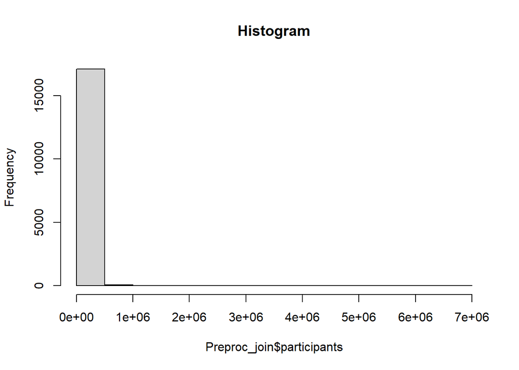

```r
###### Visual approach: Histogram, scatter plot, and boxplot
#par(mfrow=c(1,1))
hist(Preproc_join$participants, main = "Histogram")
```

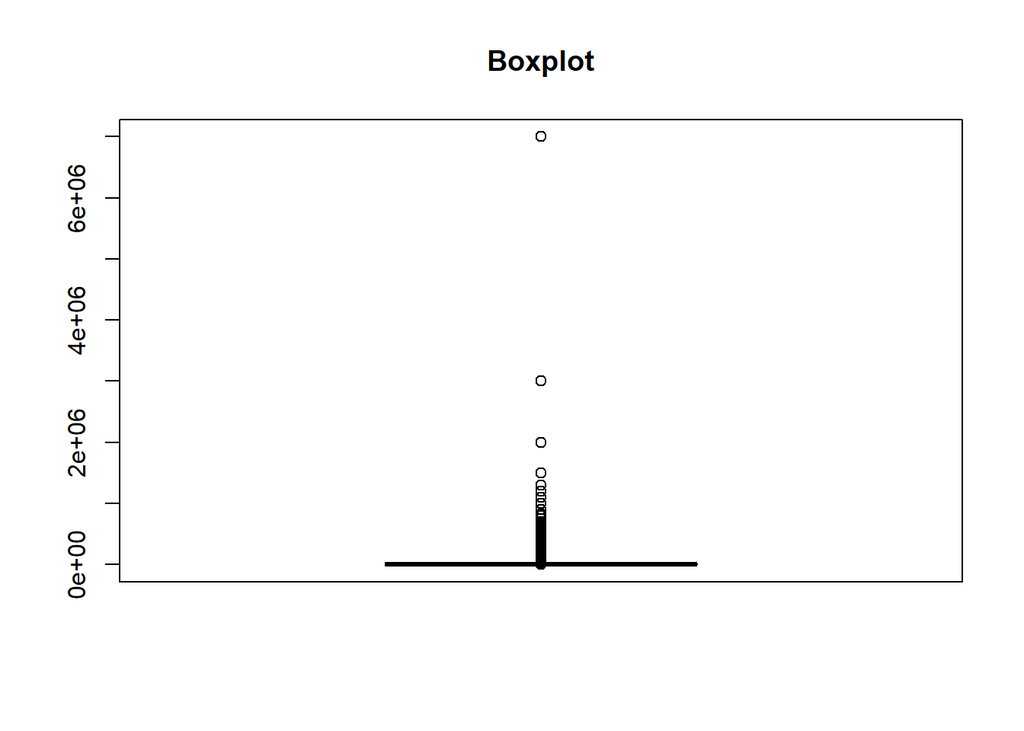

```r
boxplot(Preproc_join$participants, main = "Boxplot")
```

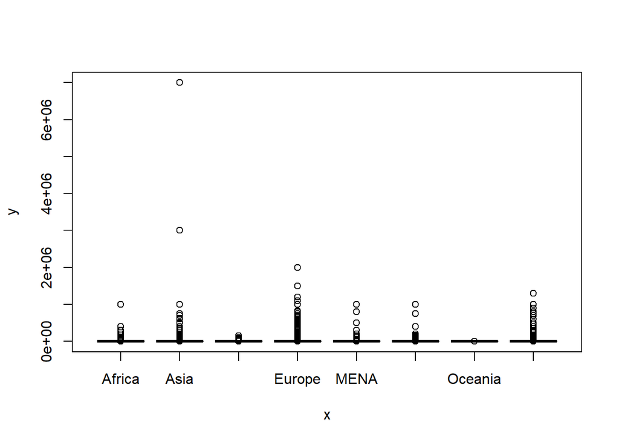

```r
plot(Preproc_join$region, Preproc_join$participants)
```

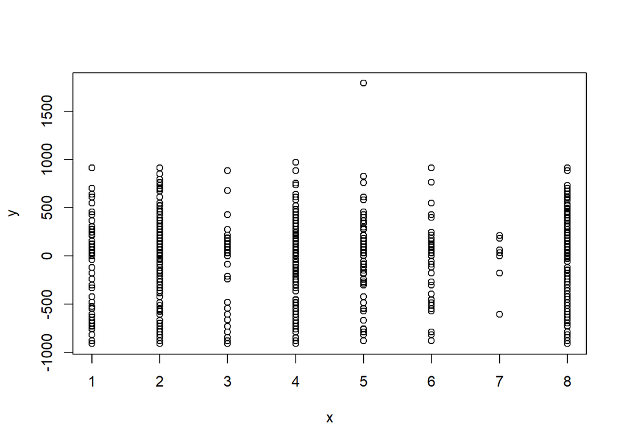

```r
plot(Preproc_join$region, Preproc_join$protest_length)
```

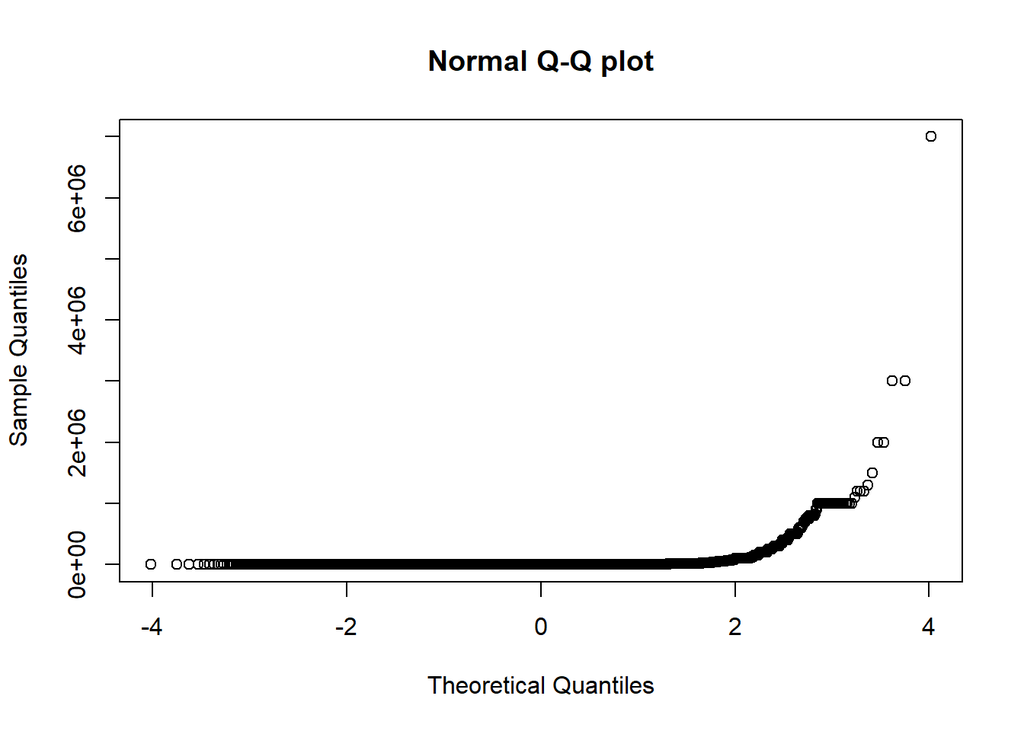

```r
qqnorm(Preproc_join$participants, main = "Normal Q-Q plot")
```

```r
###### IQR method on participants column ######
Preproc_OutIQR <- Preproc_join %>%
  select(id, region, country, protest, protestnumber, participants, start, end, participants, protesterviolence) %>%
  group_by(participants) %>%
  mutate(IQR = IQR(Preproc_join$participants),
            O_upper = quantile(participants, probs=c( .75), na.rm = FALSE)+1.5*IQR,
            O_lower = quantile(participants, probs=c( .25), na.rm = FALSE)-1.5*IQR
  ) %>%
  filter(O_lower <= participants & participants <= O_upper)

## Results: Shows No outliers present
dim(Preproc_join)
```

```
## [1] 17145    18
```

```r
dim(Preproc_OutIQR)
```

```
## [1] 17145    12
```

```r
###### Mean +/- 3 Standard Deviations

ptps = Preproc_join$participants
mean = mean(ptps)
std = sd(ptps)

Tmin = mean-(3*std)  ##find outliers
Tmax = mean+(3*std)

ptps[which(ptps < Tmin | ptps > Tmax)]   ##remove outliers
```

```
##   [1]  750000  400000 1000000  400000  500000  300000  600000  800000  900000
##  [10]  700000 1000000  700000  350000  800000  450000  300000 1000000  300000
##  [19]  300000 1300000  700000 1000000 1000000 1000000  290000 1000000 1000000
##  [28]  400000  600000  750000  900000  400000  800000  400000 1000000 1000000
##  [37]  300000  407791  750000  450000  325000  500000 1000000 2000000  500000
##  [46]  300000  700000  300000  570000  400000  300000 1000000 1000000 1200000
##  [55]  465000 1200000  825000 1100000  560000  340000  300000  400000 1200000
##  [64]  800000  350000  615000  800000  300000  500000  350000  600000  400000
##  [73]  500000  350000  450000  300000  750000  300000  600000  525000  350000
##  [82]  400000  484000  650000  300000  500000 2000000 1000000 1500000 1000000
##  [91]  300000 1000000 1000000 1000000  400000  500000  300000 1000000  350000
## [100]  400000 1000000  300000  400000  400000  300000 1000000  500000  500000
## [109]  300000  500000  800000 1000000  500000  800000  800000  300000  300000
## [118] 1000000  500000  400000  510000  350000  500000 3000000  500000  320000
## [127]  600000  700000  300000  625000  500000  400000 1000000 1000000  500000
## [136] 3000000 1000000 7000000  500000  750000 1000000
```

```r
ptps[which(ptps > Tmin & ptps < Tmax)]
```

```
##     [1]    400   1000    500    400    950    200 110000 110000   1000    400
##    [11]    400  10000   6000   3000    400    400 126000  45000    400    400
##    [21]   2000    400    500    400    400    400    250    400 170000    300
##    [31]    200    400    400  12000    200   1500    300    400    400    400
##    [41]    400    400    400    400    400    400    400    400    400    400
##    [51]    400     50    400    400    100     50     50     60    400     50
##    [61]    400    400    400    400   1000    400    400    400    400     50
##    [71]    400    400    400    400    400    400    400    400    400    400
##    [81]    400    400     50    400    400    400    400    400    400    400
##    [91]    400    400    400    400    400    400    400    400    400    400
##   [101]    400    400    400    400    400    400    400    400    400    400
##   [111]    400    400    400    400    400    400    400    400    400    400
##   [121]    400    400    400    400    400    400    400    400    400    400
##   [131]    400    400    400    400    400    400    400    400    400    400
##   [141]    400    400    400    400    400    400    400    400    400    400
```

[output cut: 1686 more lines]

```r
###### Median Absolute Deviation (MAD)

med = median(ptps)
abs_dev = abs(ptps-med)
mad = 1.4826 * median(abs_dev)

Tmin = med-(3*mad)
Tmax = med+(3*mad)

ptps[which(ptps < Tmin | ptps > Tmax)]
```

```
##    [1]  110000  110000   10000    6000  126000   45000  170000   12000   10000
##   [10]    8000    4000   15000   10000    4000    4000    5000   20000   20000
##   [19]  100000   10000    8000   30000  100000   70000   20000   80000   10000
##   [28]   10000   10000  100000  200000  200000  750000   90000   70000  150000
##   [37]  400000 1000000   11000   80000   10000   15000    8000   35000    8000
##   [46]   30000    4000   40000   10000    5000   60000   40000   20000   14000
##   [55]    6000    8000   12000    4000    6000   20000   30000   50000  100000
##   [64]    5000   10000    6000    4000   60000   30000    5000   20000    5000
##   [73]    4000   15000    5000   15000    5000   50000  150000   15000   80000
##   [82]    5000  100000   20000   10000    7000    5000   15000   14000   10000
##   [91]  200000   30000   30000  400000   30000   14000   25000  240000   50000
##  [100]    5000    5000    4500   75000  250000  500000    5000  300000  120000
##  [109]   50000    8000   13800   40000  600000  800000  100000  900000  700000
##  [118]    5000 1000000  700000   20000   12000    4000  350000   10000  800000
##  [127]  450000   10000    7000   45000  300000    8000   10000    6000    5000
```

[output cut: 233 more lines]

```r
ptps[which(ptps > Tmin & ptps < Tmax)]
```

```
##     [1]  400 1000  500  400  950  200 1000  400  400 3000  400  400  400  400
##    [15] 2000  400  500  400  400  400  250  400  300  200  400  400  200 1500
##    [29]  300  400  400  400  400  400  400  400  400  400  400  400  400  400
##    [43]  400   50  400  400  100   50   50   60  400   50  400  400  400  400
##    [57] 1000  400  400  400  400   50  400  400  400  400  400  400  400  400
##    [71]  400  400  400  400   50  400  400  400  400  400  400  400  400  400
##    [85]  400  400  400  400  400  400  400  400  400  400  400  400  400  400
##    [99]  400  400  400  400  400  400  400  400  400  400  400  400  400  400
##   [113]  400  400  400  400  400  400  400  400  400  400  400  400  400  400
##   [127]  400  400  400  400  400  400  400  400  400  400  400  400  400  400
##   [141]  400  400  400  400  400  400  400  400  400  400  400  400  400  400
##   [155]  400  400  400  400  400  400  400  400  400  400  400  400  400  400
##   [169]  400  400  400  400  100  400  400  400  400  300   80  200  200 2500
##   [183]  300  150  500  200 2000  400  400  400  400  400  400 2000   80  400
##   [197]   50  400  400   50  400  400  300   50  400  400  400  400  500  400
```

[output cut: 1051 more lines]

- Data comes in two primary shapes: *wide* and *long*.
- Dataframes often come in less-than-ideal formats, especially when you are using secondary data. Helpful to prepare it for tables or for plotting with `ggplot2`
- Wide = a row has more than one observation, and the units of observation (e.g., individuals, countries, households) are on one row each. (eg. survey or assessment data, or if you have ever downloaded data from Qualtrics)
- Long = when a row has only one observation, but the units of observation are repeated down a column. (eg. Longitudinal data)

```r
###### Inspect DF to determine if data we want is long or wide
View(Preproc_OutIQR)

###### Making long region data wide w/ pivot_wider()
ncol(Preproc_OutIQR)
```

```
## [1] 12
```

```r
Preproc_wide <-
  Preproc_OutIQR  %>%
  tidyr::pivot_wider(names_from = "region",
              values_from = "participants")
ncol(Preproc_wide)
```

```
## [1] 18
```

## sort observations and reorder columns

```r
###### Sort observations in descending order by protest startyear
Preproc_wide$start %>%
  sort(decreasing = TRUE)
```

```
##     [1] "2022-07-03 UTC" "2022-07-01 UTC" "2022-05-02 UTC" "2022-05-02 UTC"
##     [5] "2022-05-02 UTC" "2022-04-02 UTC" "2022-04-02 UTC" "2022-03-02 UTC"
##     [9] "2022-03-01 UTC" "2022-02-02 UTC" "2022-02-02 UTC" "2022-02-01 UTC"
##    [13] "2022-02-01 UTC" "2022-01-02 UTC" "2022-01-02 UTC" "2022-01-02 UTC"
##    [17] "2022-01-01 UTC" "2022-01-01 UTC" "2022-01-01 UTC" "2021-12-02 UTC"
##    [21] "2021-12-01 UTC" "2021-11-02 UTC" "2021-11-02 UTC" "2021-10-02 UTC"
##    [25] "2021-10-02 UTC" "2021-10-02 UTC" "2021-10-02 UTC" "2021-10-01 UTC"
##    [29] "2021-08-02 UTC" "2021-08-02 UTC" "2021-08-01 UTC" "2021-08-01 UTC"
##    [33] "2021-07-10 UTC" "2021-07-10 UTC" "2021-07-10 UTC" "2021-07-08 UTC"
##    [37] "2021-07-08 UTC" "2021-07-08 UTC" "2021-07-07 UTC" "2021-07-07 UTC"
##    [41] "2021-07-05 UTC" "2021-07-05 UTC" "2021-07-03 UTC" "2021-07-02 UTC"
##    [45] "2021-07-02 UTC" "2021-07-01 UTC" "2021-07-01 UTC" "2021-07-01 UTC"
##    [49] "2021-06-11 UTC" "2021-06-11 UTC" "2021-06-10 UTC" "2021-06-10 UTC"
##    [53] "2021-06-10 UTC" "2021-06-10 UTC" "2021-06-09 UTC" "2021-06-09 UTC"
##    [57] "2021-06-09 UTC" "2021-06-09 UTC" "2021-06-08 UTC" "2021-06-08 UTC"
```

[output cut: 3795 more lines]

```r
###### Reordering columns ######
head(Preproc_wide)
```

```
## # A tibble: 6 × 18
##         id country protest protestnumber start               end
##      <dbl> <fct>     <dbl>         <int> <dttm>              <dttm>
## 1   2.02e8 Canada        1             1 1991-03-01 00:00:00 1991-03-01 00:00:00
## 2   2.02e8 Canada        1             2 1992-01-06 00:00:00 1992-01-06 00:00:00
## 3   2.02e8 Canada        1             3 1990-01-07 00:00:00 1990-01-07 00:00:00
## 4   2.02e8 Canada        1             4 1990-12-07 00:00:00 1990-06-09 00:00:00
## 5   2.02e8 Canada        1             5 1991-02-08 00:00:00 1991-03-08 00:00:00
## 6   2.02e8 Canada        1             6 1991-07-09 00:00:00 1991-07-09 00:00:00
## # ℹ 12 more variables: protesterviolence <fct>, IQR <dbl>, O_upper <dbl>,
## #   O_lower <dbl>, `North America` <dbl>, `Central America` <dbl>,
## #   `South America` <dbl>, Europe <dbl>, Africa <dbl>, MENA <dbl>, Asia <dbl>,
## #   Oceania <dbl>
```

```r
Preproc_wide <- Preproc_wide %>%
  select(id, country, protest, protestnumber, start, end, protesterviolence)
```

## Aggregate Summary Stats

- Use plyr::summarise() to apply a function to the variables in a dataset, especially important for aggregating across grouping variables.
- Summarise multiple columns:
- summarise_all() affects every variable
- summarise_at() affects variables selected with a character vector or vars()
- summarise_if() affects variables selected with a predicate function
- https://dplyr.tidyverse.org/reference/summarise_all.html

```r
Preproc_long <- Preproc_NArm %>%
  arrange(region, country)
View(Preproc_long)

Preproc_long %>%
  group_by(region) %>%
  summarise(median = median(participants), n = n())
```

```
## # A tibble: 7 × 3
##   region          median     n
##   <fct>            <dbl> <int>
## 1 Africa             400   710
## 2 Asia              1000   136
## 3 Central America    200    29
## 4 Europe            1500  2027
## 5 MENA                50    87
## 6 North America      100    26
## 7 South America      100    64
```

```r
###### calculate summary statistics values by month for each variable
Preproc_long %>%
  group_by(region) %>%
  summarize(violence = sum(as.numeric(protesterviolence), na.rm = T))
```

```
## # A tibble: 7 × 2
##   region          violence
##   <fct>              <dbl>
## 1 Africa               883
## 2 Asia                 156
## 3 Central America       35
## 4 Europe              2371
## 5 MENA                  96
## 6 North America         30
## 7 South America         79
```

## Sources

- Gillespie, C. & Lovelace, R. (2016). Efficient R programming https://bookdown.org/csgillespie/efficientR/
- Wickham, H. (2014). Tidy Data. Journal of Statistical Software, 59(10), 1–23. https://doi.org/10.18637/jss.v059.i10
- Wickham, H., Çetinkaya-Rundel, M., Grolemund, G. (2023) R for Data Science, 2e. https://r4ds.hadley.nz/
- https://bookdown.org/yihui/bookdown/
- **YAML Syntax -**
- https://docs.ansible.com/ansible/latest/reference_appendices/YAMLSyntax.html
- https://rstudio.github.io/cheatsheets/html/lubridate.html?_gl=1*iabz4g*_ga*MTAwNzU0ODg4NC4xNzA1NTExNDA4*_ga_2C0WZ1JHG0*MTcwNTUxMzk2Ni4yLjEuMTcwNTUxNTExNC4wLjAuMA
- https://www.ncbi.nlm.nih.gov/pmc/articles/PMC4731595/
- https://www.jstatsoft.org/article/view/v045i03
- https://rpubs.com/brouwern/meanimpute
- **Data Wrangling with R, [UNIVERSITY of WISCONSIN–MADISONSocial Science Computing Cooperative](http://www.wisc.edu/):** https://sscc.wisc.edu/sscc/pubs/dwr/index.html